# Cointegración

Garcia Giron A

13/12/2020

En esta práctica estamos delante de los valores automovilisticos bmw y volkswagen, queremos analizar si esxiste cointegración entre el fabricante bábaro y la marca de Wolfsburgo.

¿Qué es la cointegración?

A Groso modo, se dice que dos o más series temporales estan cointegradas cuando la comparación de estas en un período t presentan una tendencia estocastica común. Vamos a seguir el método de regresión lineal y los test DF y DF aumentado para determinar si de verdad estas series estabn cointegradas.

Para esto procederemos realizando los diferentes testeos de Dickey Fuller y Dickey Fuller Aumentado. Tambien realizaremos un modelo de regresion lineal entre las dos variables y luego analizaremos sus residuales para verificar si estan o no cointegrados entre si.

```r
library(tseries)
library(quantmod)
#igual que en fundamentos revisar ese codigo
getSymbols('BMW.DE', from='2014-01-01', to='2020-11-30')
```

[output not shown]

```
## [1] "BMW.DE"
```

```r
getSymbols('VOW.DE', from='2014-01-01', to='2020-11-30')
```

```
## [1] "VOW.DE"
```

```r
BMW.DE.ret <- diff(log(Ad(BMW.DE)))  #las hacemos estacionarias
VOW.DE.ret <- diff(log(Ad(VOW.DE)))
```

```r
#trozeamos a mensual
BMW.DE.ret <- to.monthly(BMW.DE.ret)$BMW.DE.ret.Close
VOW.DE.ret <- to.monthly(VOW.DE.ret)$VOW.DE.ret.Close
vY=cbind(BMW.DE.ret,VOW.DE.ret) #aqui se incluyen los dos movimientos, generacion del vector
colnames(vY)=c("BMW","VOW") #le ponemos nombres
vY=na.omit(vY)
```

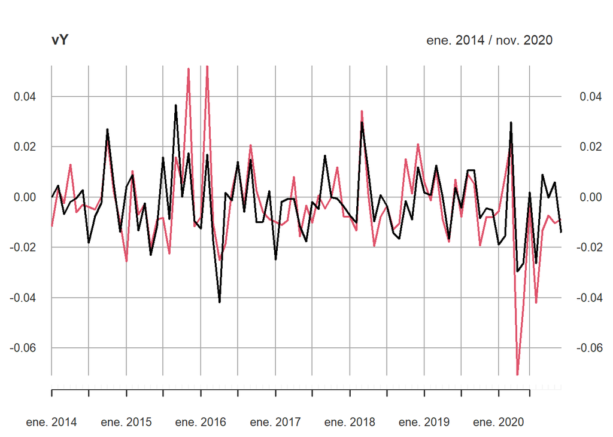

```r
plot(vY)
```

```r
adf.test(vY$BMW)  #con un p valor 0.01 rechazamos la hipotesis nula y afirmamos taxativamente que es estacionaria
```

```
##
##  Augmented Dickey-Fuller Test
##
## data:  vY$BMW
## Dickey-Fuller = -4.991, Lag order = 4, p-value = 0.01
## alternative hypothesis: stationary
```

```r
adf.test(vY$VOW) #con un p valor 0.01903 rechazamos la hipotesis nula y afirmamos taxativamente que es estacionaria
```

```
##
##  Augmented Dickey-Fuller Test
##
## data:  vY$VOW
## Dickey-Fuller = -3.8844, Lag order = 4, p-value = 0.01903
## alternative hypothesis: stationary
```

```r
library(car)
m01  <- lm(vY$BMW ~ vY$VOW)
```

```r
summary(m01)
```

```
##
## Call:
## lm(formula = vY$BMW ~ vY$VOW)
##
## Residuals:
##        Min         1Q     Median         3Q        Max
## -0.0274641 -0.0062797 -0.0000467  0.0049502  0.0284010
##
## Coefficients:
##               Estimate Std. Error t value Pr(>|t|)
## (Intercept) -0.0005409  0.0010981  -0.493    0.624
## vY$VOW       0.5539733  0.0628881   8.809  1.9e-13 ***
## ---
## Signif. codes:  0 '***' 0.001 '**' 0.01 '*' 0.05 '.' 0.1 ' ' 1
##
## Residual standard error: 0.009829 on 81 degrees of freedom
## Multiple R-squared:  0.4893, Adjusted R-squared:  0.483
## F-statistic:  77.6 on 1 and 81 DF,  p-value: 1.897e-13
```

```r
residuals <- m01$residuals
summary(residuals)
```

```
##      Index        residuals
##  Min.   :2014   Min.   :-2.746e-02
##  1st Qu.:2016   1st Qu.:-6.280e-03
##  Median :2017   Median :-4.668e-05
##  Mean   :2017   Mean   : 0.000e+00
##  3rd Qu.:2019   3rd Qu.: 4.950e-03
##  Max.   :2021   Max.   : 2.840e-02
```

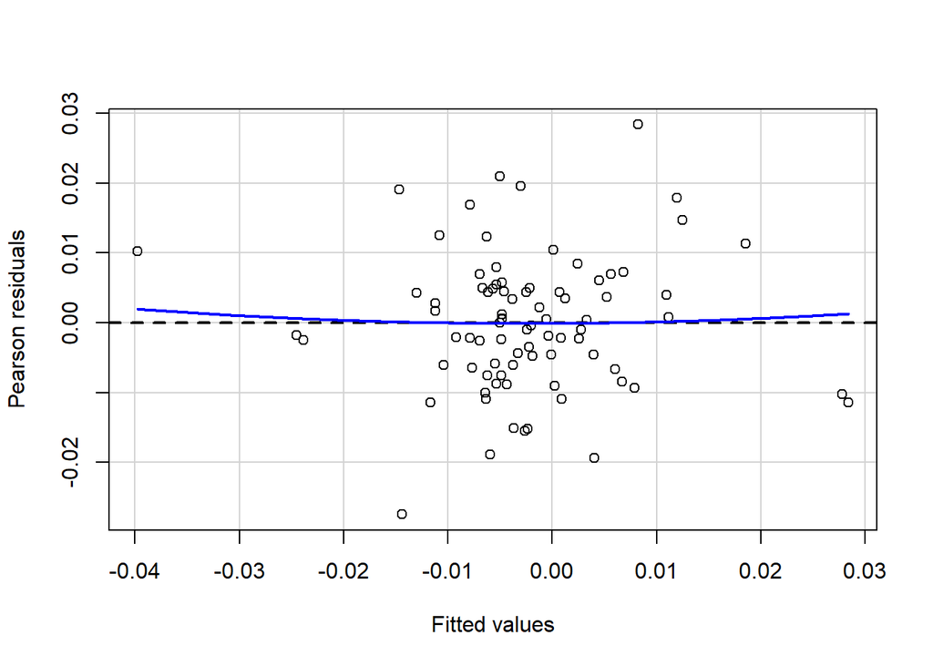

```r
residualPlot(m01)
```

Atendiendo al criterio de los residuos vemos que los errores se estabilizan en torno a la zona de la media por lo que nos ayuda a deducir la cointegracion de estos valores.

```r
adf.test(residuals)
```

```
##
##  Augmented Dickey-Fuller Test
##
## data:  residuals
## Dickey-Fuller = -4.6336, Lag order = 4, p-value = 0.01
## alternative hypothesis: stationary
```

```r
library(urca)
test <- ur.df(residuals,type = "tren", selectlags = "AIC", lags  = 10)

# p valor 0.01
summary(test)
```

```
##
## ###############################################
## # Augmented Dickey-Fuller Test Unit Root Test #
## ###############################################
##
## Test regression trend
##
##
## Call:
## lm(formula = z.diff ~ z.lag.1 + 1 + tt + z.diff.lag)
##
## Residuals:
##        Min         1Q     Median         3Q        Max
## -0.0265960 -0.0064870  0.0000589  0.0051263  0.0251353
##
## Coefficients:
##               Estimate Std. Error t value Pr(>|t|)
## (Intercept) -2.126e-03  2.907e-03  -0.731   0.4671
## z.lag.1     -1.212e+00  2.287e-01  -5.298 1.45e-06 ***
## tt           4.356e-05  5.718e-05   0.762   0.4488
## z.diff.lag1  2.268e-01  1.999e-01   1.134   0.2607
## z.diff.lag2  2.934e-01  1.667e-01   1.760   0.0830 .
## z.diff.lag3  2.415e-01  1.212e-01   1.993   0.0504 .
## ---
## Signif. codes:  0 '***' 0.001 '**' 0.01 '*' 0.05 '.' 0.1 ' ' 1
##
## Residual standard error: 0.01002 on 66 degrees of freedom
## Multiple R-squared:  0.518,  Adjusted R-squared:  0.4815
## F-statistic: 14.19 on 5 and 66 DF,  p-value: 2.026e-09
##
##
## Value of test-statistic is: -5.2982 9.3948 14.084
##
## Critical values for test statistics:
##       1pct  5pct 10pct
## tau3 -4.04 -3.45 -3.15
## phi2  6.50  4.88  4.16
## phi3  8.73  6.49  5.47
```

En esta prueba determinamos lo que gráficamente intuíamos anteriormente.